# Advanced Visualizations Lecture 03

### 3.0.3 Use qualitative colour palettes for categorical data

*Qualitative* - there is no quantitative relationship between colours. This is usually used for categorical data when you want each category to be visualized distinctly.

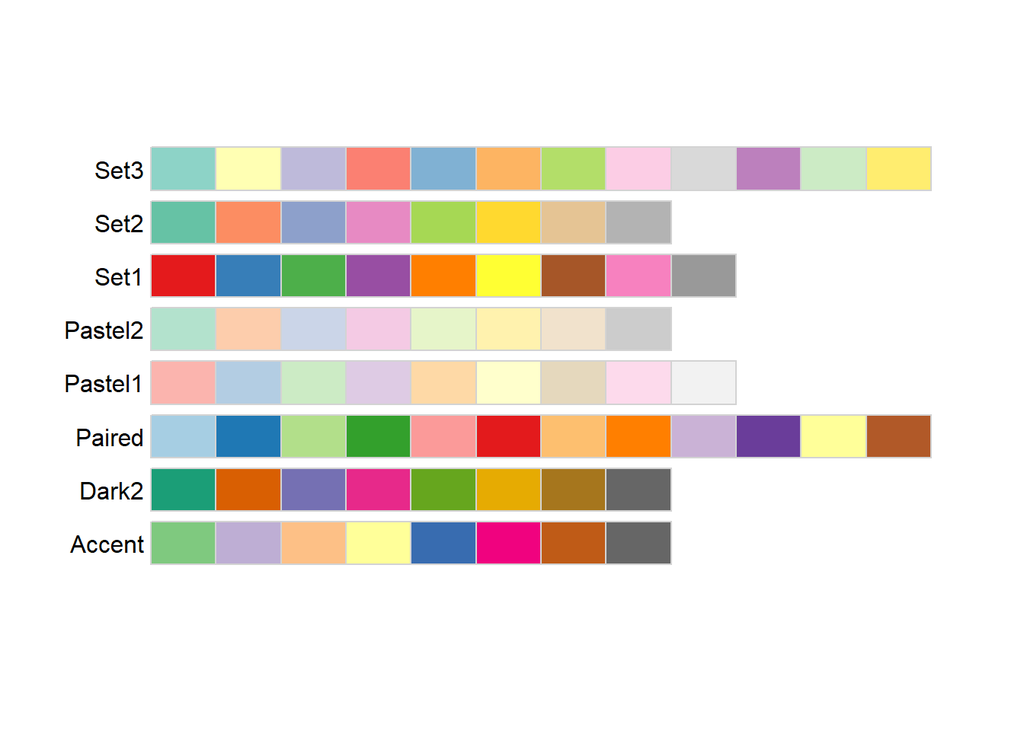

```r
display.brewer.all(type = "qual")
```

## 3.1.0 Add a colour palette to a plot like a layer

- `type`: determines the kind of palette as sequential (seq), diverging (div) or qualitative (qual)
- `palette`: accepts a string name for a palette or an integer that combines with `type` to pick a palette

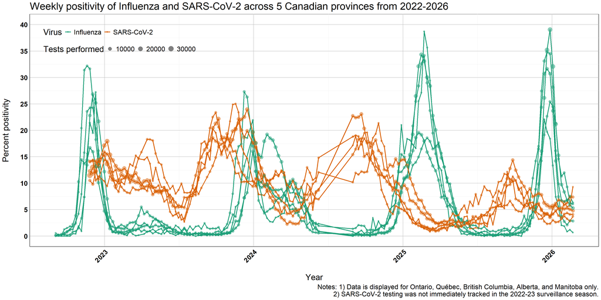

```r
# 3.1.0 add a new colour palette to our line plot

respLine.plot +

  # Use the Dark2 palette
  scale_colour_brewer(palette="Dark2")
```

Note that colour palettes *are not* vector recycled when plotting in `ggplot`. This means if you don’t supply enough colours to match your groups, then unassigned groups will simply be cut off or not displayed. In our above example, we had 8 colours in the “Dark2” palette but only needed 2 so things came out okay. If we had chosen to colour our lined individually, we would need to use someting bigger like the “Paired” colour palette or even combine some of our palettes together.

More information on palette order and other parameters can be found [here](https://ggplot2.tidyverse.org/reference/scale_brewer.html)

## 3.2.0 You can always pick your own colours!

You can always choose a vector of your own colors using this ‘R color cheatsheet’ (https://www.nceas.ucsb.edu/~frazier/RSpatialGuides/colorPaletteCheatsheet.pdf).

Names of colours as well as hex colour codes are accepted. You can supply a manual list to most aesthetics using the `scale_*_manual()` command BUT you must supply enough colours to the `values` parameter to satisfy your needs, otherwise an error will be thrown instead of just a warning.

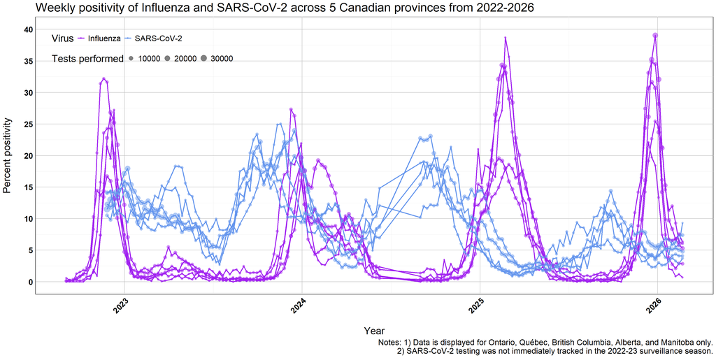

```r
# 3.2.0 Choose your own colours

respLine.plot +
    # Set your own manual colour choices
    scale_colour_manual(values=c("purple", "cornflowerblue"))
```

## 3.3.0 Colour-blind friendly palettes can be found in the `viridis` package

The main calls we can use follow the format `scale_*_viridis_c/d/b()` where the “c/d/b” represents continuous/discrete/binned data and the types of additional arguments that can be passed on to augment the call. There are some additional parameters that can be used to set the colours when called:

- `option`: accepts one of 10 possible character representing 5 colour scales; “magma”/“A”, “inferno”/“B”, “plasma”/“C”, “viridis”/“D” or “cividis”/“E”.
- `direction`: sets the direction of the palette order. Use -1 to reverse it.
- `begin` and `end`: allow you to set the start and end points along the colour spectrum in case you only want to use a portion of it.

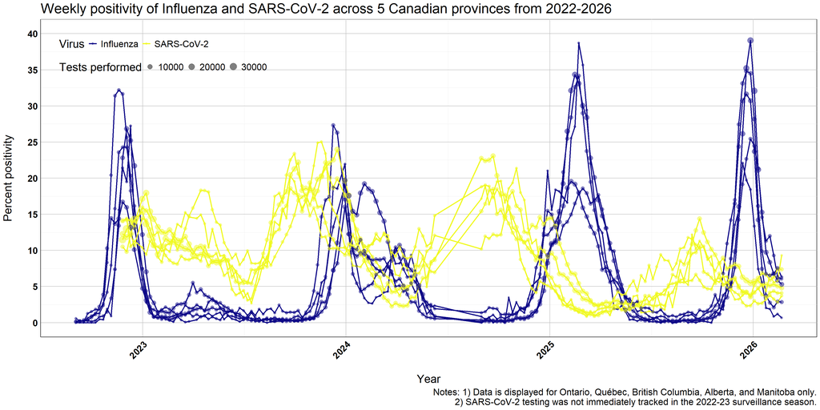

```r
# 3.3.0 apply a viridis colour palette

respLine.plot +
    # Use a colour-blind friendly palette
    scale_colour_viridis_d(option="plasma")
```

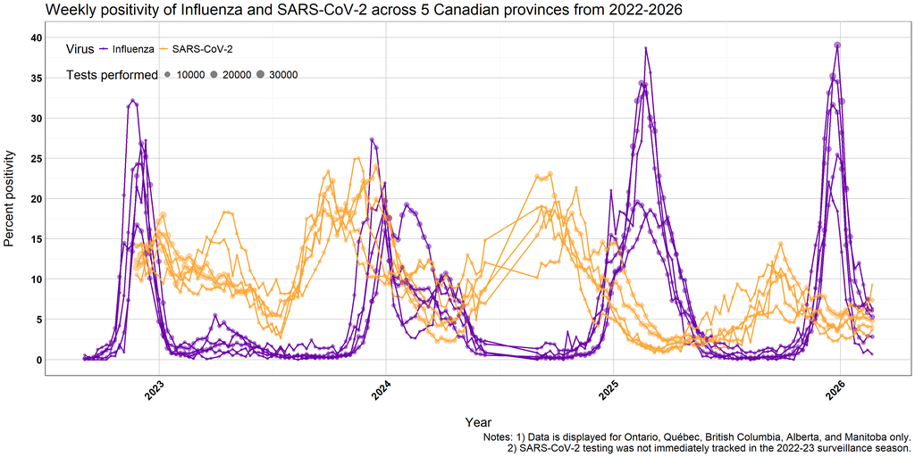

```r
# Try using a smaller section of the colour spectrum
respLine.plot +
    # Use a colour-blind friendly palette
    scale_colour_viridis_d(option="plasma", begin=0.2, end=0.8)
```